# 🌍 Democratic Republic of Congo

Land Coverage Analysis - Eastern Kivu Region

Time Series Analysis (2015-2023)

📊 9 Years 🔬 Synthetic Data 🏦 World Bank

## 📡 Data Acquisition

### ⚠️ Internet Access Required for Real Data

**This report currently uses synthetic data** because API access is unavailable.

To download real data from World Bank API, you need:

- ✓ Internet connectivity
- ✓ Access to https://api.worldbank.org
- ✓ No API keys required (World Bank API is public)

The synthetic data is based on documented deforestation rates from FAO and World Bank reports (~0.7% annual forest loss).

### World Bank API Endpoints

This script attempts to download data from the following World Bank Development Indicators:

- **Forest Coverage:** AG.LND.FRST.ZS (Forest area % of land area)
- **Agricultural Land:** AG.LND.AGRI.ZS (Agricultural land % of land area)
- **Urban Population:** SP.URB.TOTL.IN.ZS (Urban population %)

### Download Code

```
import requests
import pandas as pd

# Download forest data from World Bank API
url = "https://api.worldbank.org/v2/country/COD/indicator/AG.LND.FRST.ZS"
params = {
    'format': 'json',
    'date': '2015:2023',
    'per_page': 100
}

response = requests.get(url, params=params)
data = response.json()

forest_data = {}
for item in data[1]:
    year = int(item['date'])
    value = item['value']
    if value is not None:
        forest_data[year] = float(value)
```

### Synthetic Data Generation (Fallback)

When API access is unavailable, synthetic data is generated based on documented deforestation rates:

```
# Generate synthetic data based on documented trends
initial_forest = 62.0    # DRC Eastern Kivu baseline
initial_cropland = 25.0
initial_urban = 3.0
initial_water = 8.0
initial_bare = 2.0

for i, year in enumerate(years):
    # Apply documented deforestation rates
    forest = initial_forest * (1 - 0.007) ** i  # 0.7% loss/year
    cropland = initial_cropland * (1 + 0.015) ** i  # 1.5% growth
    urban = initial_urban * (1 + 0.035) ** i  # 3.5% growth

    # Normalize to 100%
    total = forest + cropland + urban + water + bare
    # ... store percentages
```

**Data Source:** Synthetic (based on FAO/World Bank documented rates)

**Generated:** 2026-01-11 20:50:24

## 📈 Summary Statistics

62.0%

Initial Forest (2015)

58.0%

Final Forest (2023)

-4.0pp

Forest Change

## 📊 Visualizations

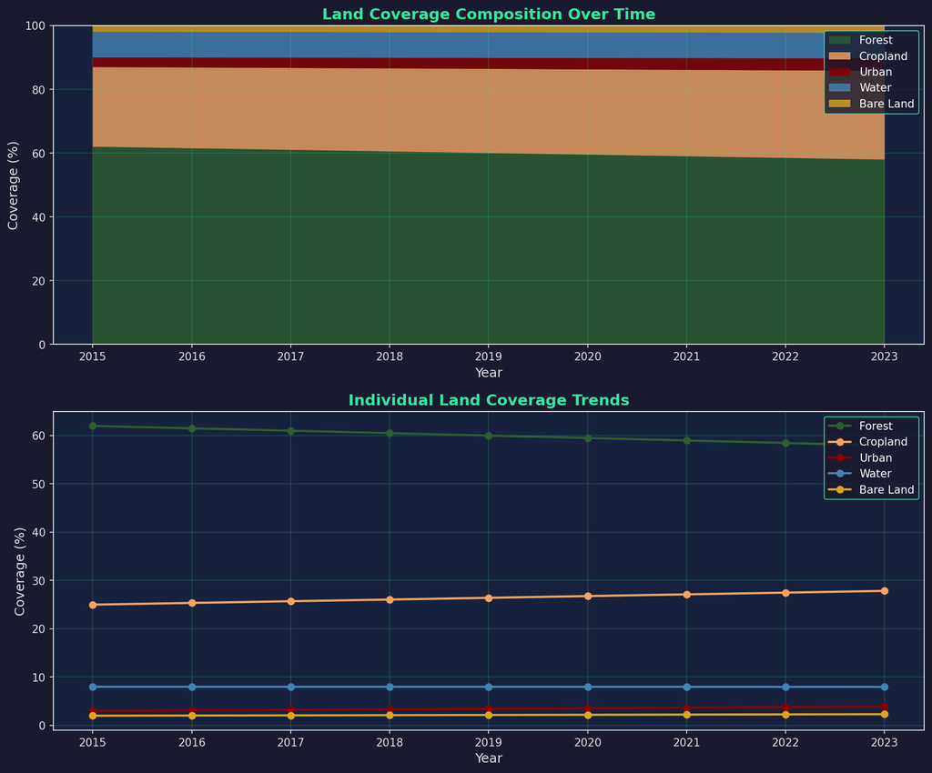

## 🗺️ Study Area Map

[interactive chart not shown]

## 📋 Data Table

| Year | Forest (%) | Cropland (%) | Urban (%) | Water (%) | Bare Land (%) |
| --- | --- | --- | --- | --- | --- |
| 2015 | 62.00 | 25.00 | 3.00 | 8.00 | 2.00 |
| 2016 | 61.51 | 25.35 | 3.10 | 8.00 | 2.04 |
| 2017 | 61.01 | 25.70 | 3.21 | 8.00 | 2.08 |
| 2018 | 60.51 | 26.06 | 3.32 | 8.00 | 2.12 |
| 2019 | 60.01 | 26.41 | 3.43 | 8.00 | 2.16 |
| 2020 | 59.50 | 26.77 | 3.54 | 7.99 | 2.19 |
| 2021 | 58.99 | 27.13 | 3.66 | 7.99 | 2.24 |
| 2022 | 58.47 | 27.49 | 3.78 | 7.98 | 2.28 |
| 2023 | 57.96 | 27.85 | 3.91 | 7.97 | 2.32 |

## 📉 Statistical Analysis

| Category | Annual Trend (pp/year) | R² Value | P-value |
| --- | --- | --- | --- |
| **Forest** | -0.506 | 1.000 | 0.0000 |
| **Cropland** | +0.356 | 1.000 | 0.0000 |
| **Urban** | +0.113 | 0.999 | 0.0000 |
| **Water** | -0.003 | 0.876 | 0.0002 |
| **Bare Land** | +0.040 | 1.000 | 0.0000 |

**Land Coverage Analysis**

Democratic Republic of Congo - Eastern Kivu Region

Data Source: Synthetic (based on FAO/World Bank documented rates)

Generated: 2026-01-11 20:50:24